# 03 - Empirical Bayes Estimation

Andrew L

11/30/2021

- don’t need to bring in prior expectations with large number of observations

Using the Lahman baseball dataset, we will prepare a dataset of players’ career averages including number of hits, at-bats, and batting avg:

```r
library(dplyr)
library(tidyr)
library(Lahman)

# Filter out pitchers
career <- Batting %>%
filter(AB > 0) %>%
anti_join(Pitching, by = "playerID") %>%
group_by(playerID) %>%
summarize(H = sum(H), AB = sum(AB)) %>%
mutate(average = H / AB)

# Include names along with the player IDs
career <- Master %>%
tbl_df() %>%
dplyr::select(playerID, nameFirst, nameLast) %>%
unite(name, nameFirst, nameLast, sep = " ") %>%
inner_join(career, by = "playerID") %>%
dplyr::select(-playerID)

career
```

```
## # A tibble: 9,802 x 4
##    name                  H    AB average
##    <chr>             <int> <int>   <dbl>
##  1 Hank Aaron         3771 12364  0.305
##  2 Tommie Aaron        216   944  0.229
##  3 Andy Abad             2    21  0.0952
##  4 John Abadie          11    49  0.224
##  5 Ed Abbaticchio      772  3044  0.254
##  6 Fred Abbott         107   513  0.209
##  7 Jeff Abbott         157   596  0.263
##  8 Kurt Abbott         523  2044  0.256
##  9 Ody Abbott           13    70  0.186
## 10 Frank Abercrombie     0     4  0
## # ... with 9,792 more rows
```

# Estimating a prior from data

- 1st step is to estimate a beta prior using data
  - usually you decide on a prior ahead of time, but empirical Bayes you use data you have
- Empirical Bayes is an **approximation** to the more exact Bayesian methods

Let’s see the distribution of the players’ batting avg, filtering out players with less than 500 at-bats:

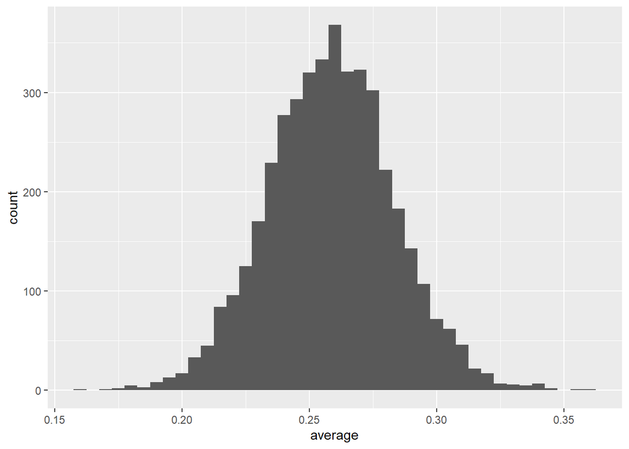

Looks like a beta distribution would be a pretty good fit. We want to fit the following model:

$$X \sim {Beta(\alpha_{0},\beta_{0})}$$

We need to pick the hyperparameters $\alpha_{0}$ and $\beta_{0}$ of our model. We can use the maximum likelihood to see which parameters would maximize the probability of generating the distribution we see

```r
library(stats4)

career_filtered <- career %>%
filter(AB > 500)

# log-likelihood function
ll <- function(alpha, beta) {
x <- career_filtered$H
total <- career_filtered$AB
-sum(VGAM::dbetabinom.ab(x, total, alpha, beta, log = TRUE)) #MLE function
}

# maximum likelihood estimation
m <- mle(ll, start = list(alpha = 1, beta = 10), method = "L-BFGS-B",
lower = c(0.0001, .1))
ab <- coef(m)
alpha0 <- ab[1]
beta0 <- ab[2]
```

Turns out $\alpha_{0} = 102$ and $\beta_{0} = 290$. Let’s see if the curve fits the distribution:

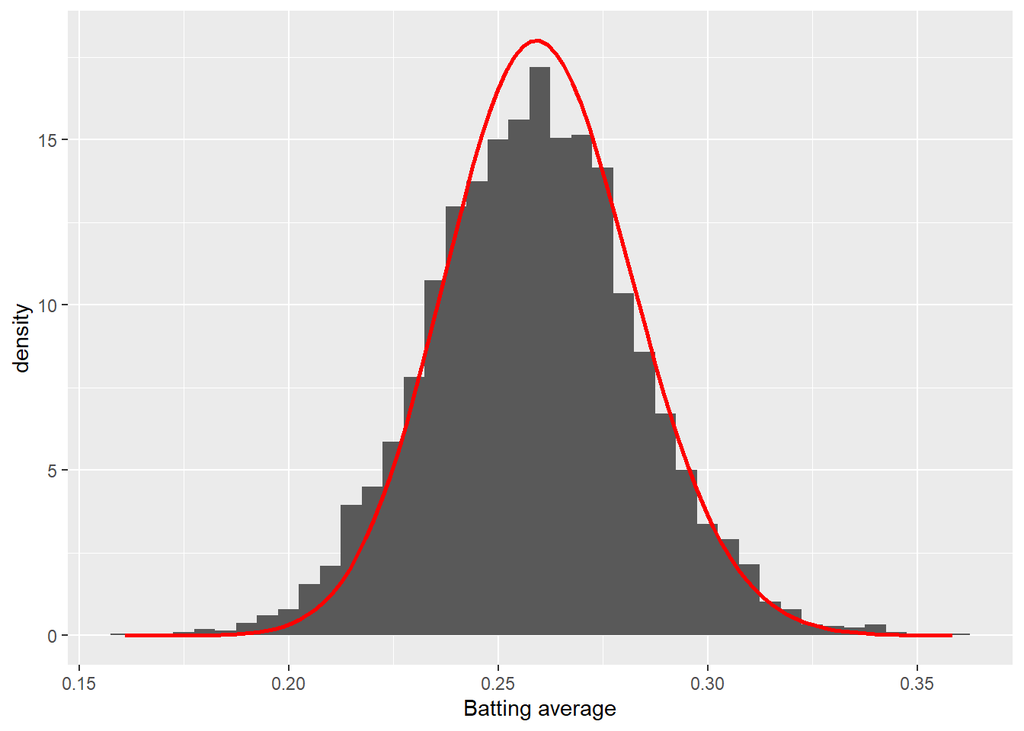

Looks like it fits pretty well!

# Using that distribution as a prior for each individual estimate

Now we can look at any individual to estimate their batting average for the rest of the season. Recall that we’re trying to update our posterior dist,:

$$Beta(\alpha_{0} + hits, \beta_{0} + misses)$$
and so to estimate any individual’s batting average, we simply use the expected value of the new distribution:

$$\frac{hits + \alpha_{0}}{hits + \alpha_{0} + misses + \beta_{0}}$$
For example, let’s compare a player with 300 hits in 1000 at bats with a player with 4 hits in 10 at bats:

$$\frac{300 + 102}{300 + 102 + 700 + 290} = 0.289$$
$$\frac{4 + 102}{4 + 102 + 6 + 290} = 0.264$$

Even though the player with 4 hits out of 10 technically has a better batting avg than the other, we guess that the 300/1000 batter is better. This is the empirical Bayes Estimate. We can save these values:

```r
career_eb <- career %>%
mutate(eb_estimate = (H + alpha0) / (AB + alpha0 + beta0))

career_eb
```

```
## # A tibble: 9,802 x 5
##    name                  H    AB average eb_estimate
##    <chr>             <int> <int>   <dbl>       <dbl>
##  1 Hank Aaron         3771 12364  0.305        0.304
##  2 Tommie Aaron        216   944  0.229        0.238
##  3 Andy Abad             2    21  0.0952       0.252
##  4 John Abadie          11    49  0.224        0.256
##  5 Ed Abbaticchio      772  3044  0.254        0.254
##  6 Fred Abbott         107   513  0.209        0.231
##  7 Jeff Abbott         157   596  0.263        0.262
##  8 Kurt Abbott         523  2044  0.256        0.257
##  9 Ody Abbott           13    70  0.186        0.249
## 10 Frank Abercrombie     0     4  0            0.258
## # ... with 9,792 more rows
```

We can now observe and compare between their batting averages and their empirical Bayes estimate of their batting average, allowing us to gauge more into each players’ true performances.

Let’s see how the empirical Bayes estimates changed all of the batting average estimates using a scatterplot:

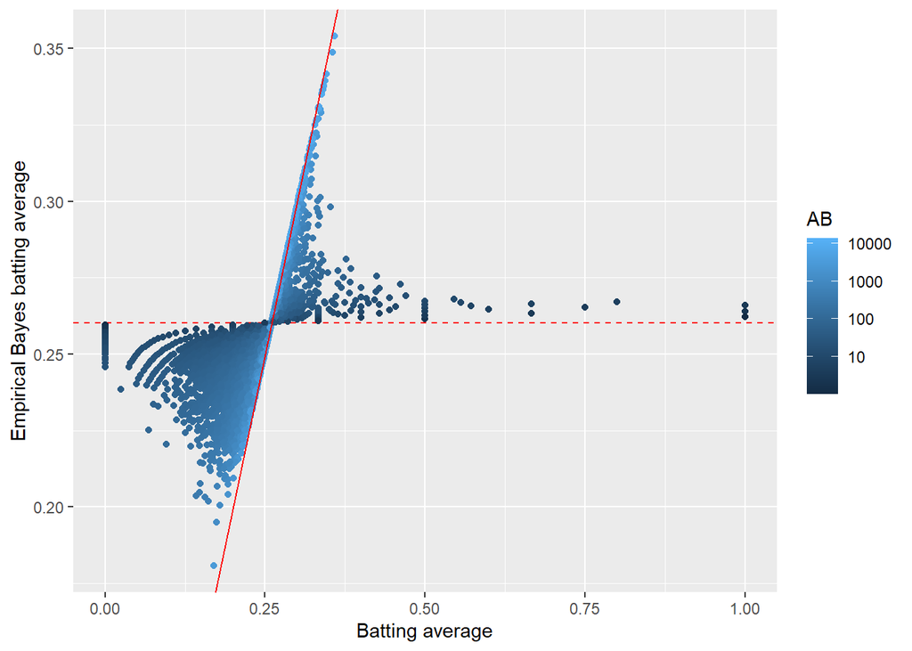

```r
ggplot(career_eb, aes(average, eb_estimate, color = AB)) +
  geom_hline(yintercept = alpha0 / (alpha0 + beta0), color = "red", lty = 2) +
  geom_point() +
  geom_abline(color = "red") +
  scale_colour_gradient(trans = "log", breaks = 10 ^ (1:5)) +
  xlab("Batting average") +
  ylab("Empirical Bayes batting average")
```

The red dotted line represents the expected value with no evidence $\frac{\alpha_{0}}{\alpha_{0}+\beta_{0}} = 0.261$. The diagonal red line marks $x=y$, points that are close to this line, are ones that didn’t get shrink much by empirical Bayes. These points are usually the ones with highest number of at-bats marked in brighter blue; they have enough evidence that we are willing to believe the naive batting avg estimate.

In general, if we have very little evidence, the observation will more likely be shrunk more compared to observations with lots of evidence.